# Week 6 - Day 2 - Homework

12/04/2022

```r
library(tidyverse)
library(janitor)
```

**Distributions homework**

You are given a cut of a database containing details of mobile phones and their customer reviews on an online shopping site in file 20190928-items.csv. Each row in the data corresponds to one model of mobile phone. Use the data to answer the following questions.

As part of the MVP we want you not to just run the code but also have a go at intepreting the results - this is the main learning objective from this homework. Don’t worry if you aren’t sure, it’s ok to get it wrong, but give it a go, through trying we will learn.

1 MVP

**Question 1.** Load the data, clean_names() and explore it.

```r
mobile_reviews <- read_csv("data/20190928-items.csv")
mobile_reviews %>%
  clean_names()
```

| asin | brand | title | url | image | rating | review_url | total_reviews | prices |
| --- | --- | --- | --- | --- | --- | --- | --- | --- |
| B0000SX2UC | Nokia | Dual-Band / Tri-Mode Sprint PCS Phone w/ Voice Activated Dialing & Bright White Backlit Screen | https://www.amazon.com/Dual-Band-Tri-Mode-Activated-Dialing-Backlit/dp/B0000SX2UC | https://m.media-amazon.com/images/I/2143EBQ210L._AC_UY218_SEARCH213888_FMwebp_QL75_.jpg | 3.0 | https://www.amazon.com/product-reviews/B0000SX2UC | 14 | NA |
| B0009N5L7K | Motorola | Motorola I265 phone | https://www.amazon.com/Motorola-i265-I265-phone/dp/B0009N5L7K | https://m.media-amazon.com/images/I/419WBAVDARL._AC_UY218_SEARCH213888_FMwebp_QL75_.jpg | 2.9 | https://www.amazon.com/product-reviews/B0009N5L7K | 7 | $49.95 |
| B000SKTZ0S | Motorola | MOTOROLA C168i AT&T CINGULAR PREPAID GOPHONE CELL PHONE | https://www.amazon.com/MOTOROLA-C168i-CINGULAR-PREPAID-GOPHONE/dp/B000SKTZ0S | https://m.media-amazon.com/images/I/71b+q3ydkIS._AC_UY218_SEARCH213888_FMwebp_QL75_.jpg | 2.6 | https://www.amazon.com/product-reviews/B000SKTZ0S | 22 | NA |
| B00198M12M | Nokia | Nokia 6500 Slide Black/silver Unlocked Cell Phone | https://www.amazon.com/Nokia-6500-Slide-silver-Unlocked/dp/B00198M12M | https://m.media-amazon.com/images/I/41ss4HpLkLL._AC_UY218_SEARCH213888_FMwebp_QL75_.jpg | 2.4 | https://www.amazon.com/product-reviews/B00198M12M | 5 | NA |
| B001AO4OUC | Motorola | Motorola i335 Cell Phone Boost Mobile | https://www.amazon.com/Motorola-i335-Phone-Boost-Mobile/dp/B001AO4OUC | https://m.media-amazon.com/images/I/710UO8gdT+L._AC_UY218_SEARCH213888_FMwebp_QL75_.jpg | 3.3 | https://www.amazon.com/product-reviews/B001AO4OUC | 21 | NA |
| B001DCJAJG | Motorola | Motorola V365 no contract cellular phone AT&T | https://www.amazon.com/Motorola-V365-contract-cellular-phone/dp/B001DCJAJG | https://m.media-amazon.com/images/I/61LYNCVrrKL._AC_UY218_SEARCH213888_FMwebp_QL75_.jpg | 3.2 | https://www.amazon.com/product-reviews/B001DCJAJG | 12 | NA |
| B001DZY4KI | Sony | Sony Ericsson G700 Triband GSM Phone Bronze (Unlocked) | https://www.amazon.com/Sony-Ericsson-Triband-Bronze-Unlocked/dp/B001DZY4KI | https://m.media-amazon.com/images/I/51mL10InzcL._AC_UY218_SEARCH213888_FMwebp_QL75_.jpg | 2.0 | https://www.amazon.com/product-reviews/B001DZY4KI | 1 | $78.99 |
| B001GQ3DJM | Nokia | Nokia 1680 Black Phone (T-Mobile) | https://www.amazon.com/Nokia-1680-Black-Phone-T-Mobile/dp/B001GQ3DJM | https://m.media-amazon.com/images/I/41X4VeqkFOL._AC_UY218_SEARCH213888_FMwebp_QL75_.jpg | 2.7 | https://www.amazon.com/product-reviews/B001GQ3DJM | 3 | NA |
| B0027VKQPE | Nokia | Nokia New 1100 for Tracfone | https://www.amazon.com/New-Nokia-1100-for-Tracfone/dp/B0027VKQPE | https://m.media-amazon.com/images/I/91IUe3nDP7L._AC_UY218_SEARCH213888_FMwebp_QL75_.jpg | 3.2 | https://www.amazon.com/product-reviews/B0027VKQPE | 8 | $99.99 |
| B00280QJFU | Samsung | Samsung T301G Prepaid Phone (Tracfone) | https://www.amazon.com/Samsung-T301G-Prepaid-Phone-Tracfone/dp/B00280QJFU | https://m.media-amazon.com/images/I/71QX+Kiri4L._AC_UY218_SEARCH213888_FMwebp_QL75_.jpg | 3.5 | https://www.amazon.com/product-reviews/B00280QJFU | 133 | $59.89 |

[output cut: 782 more lines]

```r
view(mobile_reviews)
names(mobile_reviews)
```

```
[1] "asin"         "brand"        "title"
[4] "url"          "image"        "rating"
[7] "reviewUrl"    "totalReviews" "prices"
```

```r
glimpse(mobile_reviews)
```

```
Rows: 792
Columns: 9
$ asin         <chr> "B0000SX2UC", "B0009N5L7K", "B~
$ brand        <chr> "Nokia", "Motorola", "Motorola~
$ title        <chr> "Dual-Band / Tri-Mode Sprint P~
$ url          <chr> "https://www.amazon.com/Dual-B~
$ image        <chr> "https://m.media-amazon.com/im~
$ rating       <dbl> 3.0, 2.9, 2.6, 2.4, 3.3, 3.2, ~
$ reviewUrl    <chr> "https://www.amazon.com/produc~
$ totalReviews <dbl> 14, 7, 22, 5, 21, 12, 1, 3, 8,~
$ prices       <chr> NA, "$49.95", NA, NA, NA, NA, ~
```

```r
head(mobile_reviews, 10)
```

| asin | brand | title | url | image | rating | reviewUrl | totalReviews | prices |
| --- | --- | --- | --- | --- | --- | --- | --- | --- |
| B0000SX2UC | Nokia | Dual-Band / Tri-Mode Sprint PCS Phone w/ Voice Activated Dialing & Bright White Backlit Screen | https://www.amazon.com/Dual-Band-Tri-Mode-Activated-Dialing-Backlit/dp/B0000SX2UC | https://m.media-amazon.com/images/I/2143EBQ210L._AC_UY218_SEARCH213888_FMwebp_QL75_.jpg | 3.0 | https://www.amazon.com/product-reviews/B0000SX2UC | 14 | NA |
| B0009N5L7K | Motorola | Motorola I265 phone | https://www.amazon.com/Motorola-i265-I265-phone/dp/B0009N5L7K | https://m.media-amazon.com/images/I/419WBAVDARL._AC_UY218_SEARCH213888_FMwebp_QL75_.jpg | 2.9 | https://www.amazon.com/product-reviews/B0009N5L7K | 7 | $49.95 |
| B000SKTZ0S | Motorola | MOTOROLA C168i AT&T CINGULAR PREPAID GOPHONE CELL PHONE | https://www.amazon.com/MOTOROLA-C168i-CINGULAR-PREPAID-GOPHONE/dp/B000SKTZ0S | https://m.media-amazon.com/images/I/71b+q3ydkIS._AC_UY218_SEARCH213888_FMwebp_QL75_.jpg | 2.6 | https://www.amazon.com/product-reviews/B000SKTZ0S | 22 | NA |
| B00198M12M | Nokia | Nokia 6500 Slide Black/silver Unlocked Cell Phone | https://www.amazon.com/Nokia-6500-Slide-silver-Unlocked/dp/B00198M12M | https://m.media-amazon.com/images/I/41ss4HpLkLL._AC_UY218_SEARCH213888_FMwebp_QL75_.jpg | 2.4 | https://www.amazon.com/product-reviews/B00198M12M | 5 | NA |
| B001AO4OUC | Motorola | Motorola i335 Cell Phone Boost Mobile | https://www.amazon.com/Motorola-i335-Phone-Boost-Mobile/dp/B001AO4OUC | https://m.media-amazon.com/images/I/710UO8gdT+L._AC_UY218_SEARCH213888_FMwebp_QL75_.jpg | 3.3 | https://www.amazon.com/product-reviews/B001AO4OUC | 21 | NA |
| B001DCJAJG | Motorola | Motorola V365 no contract cellular phone AT&T | https://www.amazon.com/Motorola-V365-contract-cellular-phone/dp/B001DCJAJG | https://m.media-amazon.com/images/I/61LYNCVrrKL._AC_UY218_SEARCH213888_FMwebp_QL75_.jpg | 3.2 | https://www.amazon.com/product-reviews/B001DCJAJG | 12 | NA |
| B001DZY4KI | Sony | Sony Ericsson G700 Triband GSM Phone Bronze (Unlocked) | https://www.amazon.com/Sony-Ericsson-Triband-Bronze-Unlocked/dp/B001DZY4KI | https://m.media-amazon.com/images/I/51mL10InzcL._AC_UY218_SEARCH213888_FMwebp_QL75_.jpg | 2.0 | https://www.amazon.com/product-reviews/B001DZY4KI | 1 | $78.99 |
| B001GQ3DJM | Nokia | Nokia 1680 Black Phone (T-Mobile) | https://www.amazon.com/Nokia-1680-Black-Phone-T-Mobile/dp/B001GQ3DJM | https://m.media-amazon.com/images/I/41X4VeqkFOL._AC_UY218_SEARCH213888_FMwebp_QL75_.jpg | 2.7 | https://www.amazon.com/product-reviews/B001GQ3DJM | 3 | NA |
| B0027VKQPE | Nokia | Nokia New 1100 for Tracfone | https://www.amazon.com/New-Nokia-1100-for-Tracfone/dp/B0027VKQPE | https://m.media-amazon.com/images/I/91IUe3nDP7L._AC_UY218_SEARCH213888_FMwebp_QL75_.jpg | 3.2 | https://www.amazon.com/product-reviews/B0027VKQPE | 8 | $99.99 |
| B00280QJFU | Samsung | Samsung T301G Prepaid Phone (Tracfone) | https://www.amazon.com/Samsung-T301G-Prepaid-Phone-Tracfone/dp/B00280QJFU | https://m.media-amazon.com/images/I/71QX+Kiri4L._AC_UY218_SEARCH213888_FMwebp_QL75_.jpg | 3.5 | https://www.amazon.com/product-reviews/B00280QJFU | 133 | $59.89 |

**Question 2.** Find the brand with the highest numbers of phones in the dataset.

```r
mobile_reviews %>%
  group_by(brand) %>%
  summarise(phone_count = n()) %>%
  arrange(desc(phone_count))
```

| brand | phone_count |
| --- | --- |
| Samsung | 397 |
| Apple | 101 |
| Motorola | 100 |
| Nokia | 49 |
| HUAWEI | 36 |
| Google | 33 |
| Sony | 29 |
| Xiaomi | 27 |
| ASUS | 13 |
| OnePlus | 7 |

```r
# The brand with the highest number of models in the dataset is Samsung with 397
# phones
```

**Question 3.** For your top brand, plot the distribution of phone ratings as a probability density, overlaying a fitted normal distribution. Do you think the normal distribution provides a good model of these ratings? - Hint - You will need to calculate the mean() and sd() of the ratings to plot the appropriate normal distribution. Alternatively, investigate using the fitdistr() function in the MASS package]

```r
samsung_only <- mobile_reviews %>%
  filter(brand == "Samsung")

samsung_only %>%
  summarise(
    mean_samsung_ratings = mean(rating),
    sd_samsung_ratings = sd(rating)
  )
```

| mean_samsung_ratings | sd_samsung_ratings |
| --- | --- |
| 3.5733 | 0.6847859 |

```r
# mean is 3.57
# SD is 0.68

# use a probability density function
# it's 1 to 5 but goes up in .10s
#
# rating = seq(1, 5, by = 0.1),
```

WHAT I HAVE DONE BELOW IS WRONG (I forgot to put in ..density.. as I got confused, but I think my line is correct) - see answers from class after the below

```r
samsung_ratings_distribution <- tibble(
  x = seq(1, 5, by = 0.1),
  y = dnorm(x = x, mean = 3.57, sd = 0.68),
  normal = dnorm(x = x, mean = 3, sd = 0.5),
  another_normal = dnorm(x = x, mean = 3, sd = 1)
)
samsung_ratings_distribution
```

| x | y | normal | another_normal |
| --- | --- | --- | --- |
| 1.0 | 0.0004641732 | 0.0002676605 | 0.05399097 |
| 1.1 | 0.0008005032 | 0.0005838939 | 0.06561581 |
| 1.2 | 0.0013509954 | 0.0012238039 | 0.07895016 |
| 1.3 | 0.0022312719 | 0.0024644383 | 0.09404908 |
| 1.4 | 0.0036062758 | 0.0047681764 | 0.11092083 |
| 1.5 | 0.0057039168 | 0.0088636968 | 0.12951760 |
| 1.6 | 0.0088286694 | 0.0158309032 | 0.14972747 |
| 1.7 | 0.0133728860 | 0.0271659385 | 0.17136859 |
| 1.8 | 0.0198227019 | 0.0447890606 | 0.19418605 |
| 1.9 | 0.0287546692 | 0.0709491857 | 0.21785218 |

[output cut: 31 more lines]

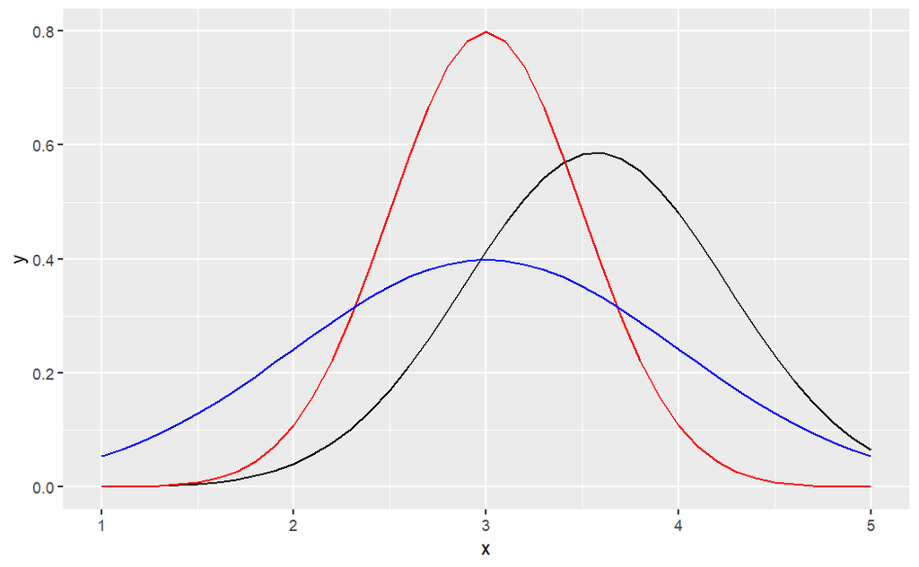

```r
# I'm not sure what to put the normal SD as... I thought 1 but it doesn't look quite right (blue line)? And I just presumed I make the mean 3 as it's in the middle of 1 and 5?

samsung_ratings_distribution %>%
  ggplot() +
  geom_line(aes(x = x, y = y), col = "black") +
  geom_line(aes(x = x, y = normal), col = "red") +
  geom_line(aes(x = x, y = another_normal), col = "blue")
```

answer from class

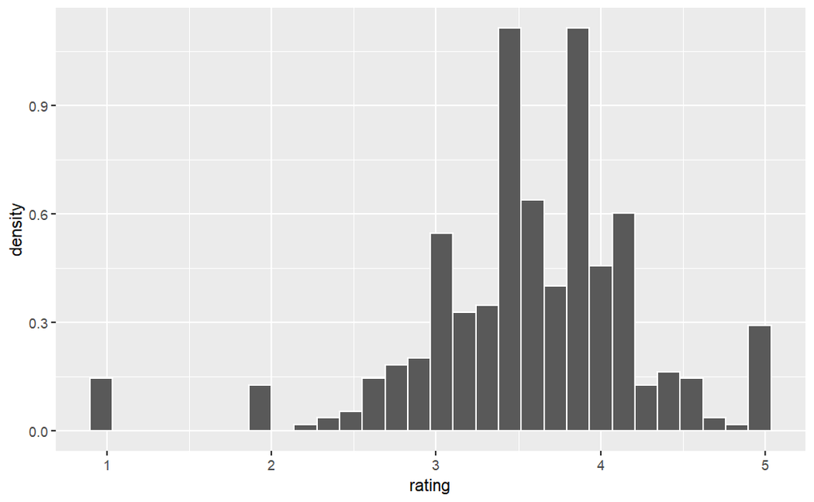

```r
samsung_stats <- samsung_only %>%
  summarise(
    mean_samsung_ratings = mean(rating),
    sd_samsung_ratings = sd(rating)
  )

samsung_only %>%
  ggplot(aes(x = rating)) +
  geom_histogram(aes(y = ..density..), col = "white") +
  stat_function(
    fun = dnorm,
    args = list(
      mean = samsung_stats$mean,
      sd = samsung_stats$sd
    ),
    col = "red"
  )
```

“It’s a reasonable fit: the distribution is roughly bell-shaped. The main problems seem to be a larger number of ratings in the tails of the distribution than are predicted by the normal, at ratings 1, 2 and 5”

**Question 4.** We can be more quantitative in comparing the distribution of top brand ratings with a normal distribution. You calculated the mean() and sd() of your distribution in an earlier question. Use these values to calculate the proportions of ratings within one-, two- and three standard deviations of the mean. Compare these proportions with those you expect for a normal distribution.

*Hint* You can use a filter() to get only the ratings within one-, two- and three standard deviations of the mean, and then think about how to calculate what proportion each of these filtered sets make of the total number of ratings. You’ll need to use three separate filter() and summarise() pipes to do this. *Further hint - code to filter within one SD* Here’s the code to filter and summarise the proportion of ratings within one standard deviation of the mean.

```r
samsung_stats <- samsung_only %>%
  summarise(
    mean = mean(rating),
    sd = sd(rating)
  )

samsung_only %>%
  filter(rating >= samsung_stats$mean - samsung_stats$sd) %>%
  filter(rating <= samsung_stats$mean + samsung_stats$sd) %>%
  summarise(prop_within_1sd = n() / nrow(samsung_only))
```

| prop_within_1sd |
| --- |
| 0.7934509 |

For a normal distribution:

```r
100 * (pnorm(q = 1) - pnorm(q = -1))
```

```
[1] 68.26895
```

```r
# 68.27 within one sd
100 * (pnorm(q = 2) - pnorm(q = -2))
```

```
[1] 95.44997
```

```r
100 * (pnorm(q = 3) - pnorm(q = -3))
```

```
[1] 99.73002
```

i was correct for 1 SD… for 2 and 3 (answer from class - need to change names for it to work):

```r
samsung_ratings %>%
  filter(rating >= samsung_stats$mean - 2 * samsung_stats$sd) %>%
  filter(rating <= samsung_stats$mean + 2 * samsung_stats$sd) %>%
  summarise(prop_within_2sd = n() / nrow(samsung_ratings))
```

[output not shown]

```r
samsung_ratings %>%
  filter(rating >= samsung_stats$mean - 3 * samsung_stats$sd) %>%
  filter(rating <= samsung_stats$mean + 3 * samsung_stats$sd) %>%
  summarise(prop_within_3sd = n() / nrow(samsung_ratings))
```

[output not shown]

“For a normal distribution, expect 68% of values to fall within one standard deviation of the mean. Here, 79% of ratings are within this range, so our distribution is slightly too central.

Adding another standard deviation to either side should increase the proportion of values by 27% to 95% overall in a normal distribution. Our distribution adds 13%, going to 92% overall, so there are too few values in the range from one- to two standard deviations.